# Monarch Assistant/ChatGPT Plugin Evals

Shawn T O’Neil

2023-10-23

Source repo for this document: https://github.com/monarch-initiative/oai-plugin-evals/

## Background

This report shows preliminary evaluations for a snapshot of the [Monarch Assistant](https://monarch-assistant.streamlit.app/)), a self-deployed version of the [Monarch ChatGPT Plugin](https://monarchinit.medium.com/knowledge-backed-ai-with-monarch-a-match-made-in-heaven-a8296eec6b9f), on portions of the [GeneTuring](https://www.biorxiv.org/content/10.1101/2023.03.11.532238v1.abstract) evaluation benchmark.

Both versions are based on the same technology: [function-calling](https://openai.com/blog/function-calling-and-other-api-updates) features available in OpenAI `gpt-3.5-turbo-0604` and `gpt-4-0604` models. During a chat the list of available functions is provided to the model. Model function call messages are translated to requests to a [simplified Monarch API](https://oai-monarch-plugin.monarchinitiative.org/openapi.json) ([github](https://github.com/monarch-initiative/oai-monarch-plugin)), which provides low-token access in front of the general [Monarch API](https://api-v3.monarchinitiative.org/v3/docs). API responses are fed back to the model, at which point it may summarize the information for the user, or decide to make a followup call if appropriate.

[figure not shown]

The API wrapper currently supports a limited subset of Monarch functionality:

- Search
- Disease <-> Gene association lookup
- Gene <-> Phenotype association lookup
- Phenotype <-> Disease association lookup

#### GeneTuring Benchmark

[GeneTuring](https://www.biorxiv.org/content/10.1101/2023.03.11.532238v1.abstract) is a benchmark dataset for genetic/genomic question and answer tasks.[^1] The benchmark consists of 50 questions in each of 12 modules. Some examples:

- “Module”: Gene alias”, “Question”: “What is the official gene symbol of LMP10?”, “Goldstandard”: “PSMB10”
- “Module”: “Gene disease association”, “Question”: “What are genes related to Distal renal tubular acidosis?”, “Goldstandard”: “SLC4A1, ATP6V0A4”
- “Module”: “Gene location”, “Question”: “Which chromosome is RP11-17A4.3 gene located on human genome?”, “Goldstandard”: “chr8”
- “Module”: “Gene ontology”, “Question”: “What is the enriched gene ontology term associated with FMR1, FBXL2, TMEM41B, PHB1, DDX56?”, “Goldstandard”: “modulation by host of viral rna genome replication”
- “Module”: “Human genome DNA aligment”, “Question”: “Align the DNA sequence to the human genome:TGAGAGCACAGTGGTGA[truncaded]”, “Goldstandard”: “chr1:234883857-234883957”
- “Module”: “Multi-species DNA aligment”, “Question”: “Which organism does the DNA sequence come from:TTCAATTCTCTGTAGGCAAGGA[truncated]”, “Goldstandard”: “rat”
- “Module”: “Gene name conversion”, “Question”: “Convert ENSG00000205403 to official gene symbol.”, “Goldstandard”: “CFI”
- “Module”: “Gene name extraction”, “Question”: “What are the gene and protein names in the sentence: The H5 mutants were: DH5 (all amino acids in D configuration) and H5F (where all His are replaced by Phe at positions 3, 7, 8, 15, 18, 19, 21).?”, “Goldstandard”: “H5 mutants, DH5, H5F” (Note: gold standard may be “No gene”)
- “Module”: “Protein-coding genes”, “Question”: “Is NODAL a protein-coding gene?”, “Goldstandard”: “TRUE” (Note: gold standard may be null to indicate false)
- “Module”: “Gene SNP association”, “Question”: “Which gene is SNP rs1217074595 associated with?”, “Goldstandard”: “LINC01270”
- “Module”: “SNP location”, “Question”: “Which chromosome does SNP rs545148486 locate on human genome?”, “Goldstandard”: “chr16”
- “Module”: “TF regulation”, “Question”: “Does transcription factor ETV4 activate or repress gene ERBB2?”, “Goldstandard”: “Repression”

## Methods

We evaluate two modules fit for the Monarch Assistant: “Gene alias” and “Gene disease association”. Questions and answer scoring for these modules are generated by the GeneTuring authors as follows. *Note the use of OMIM for gene-disease association data, which is also a Monarch data source.*

**Gene alias**: “The information of official gene names and their aliases for human protein-coding genes was downloaded from NCBI website13. 50 genes with at least one alias were randomly selected. For each gene, one alias was randomly selected to produce the question.” For scoring, the authors suggest a Jaccard index, comparing the set of names mentioned in an answer to the (single) official gene name.

**Gene disease association**: “Gene-disease association information was downloaded from OMIM website. 50 diseases were randomly selected and all genes associated with each disease were recorded.” Scoring uses a basic accuracy score, computing the percentage of gold-standard genes mentioned in an answer.

Models evaluated:

- **3.5 Base**: GPT-3.5 based model with no access to Monarch APIs for comparison purposes.
- **4 Base**: GPT-4 based model with no access to Monarch APIs for comparison purposes.
- **3.5 + Monarch**: GPT-3.5 based Monarch Assistant with access to the Monarch wrapper API.
- **4 + Monarch**: GPT-4 based Monarch Assistant with access to the Monarch wrapper API. This model should be most similar to that provided by the ChatGPT plugin, though minor differences may occur do to function-calling implementation details or model differences used by plugins.

Response scoring is handled by Evaluator Agents, provided with callable functions to extract mentioned gene names and compute the relevant scoring statistics ([GitHub](https://github.com/monarch-initiative/oai-plugin-evals/blob/main/src/oai_plugin_evals/agents.py)). This strategy seems to work well, though there’s a growing literature on proper model-based evaluation and we will need to perform some human evaluation for validation.

## Results

Most scores were either `1.0` (perfect according to each tasks’ respective scoring criteria) or `0.0`, but in a few cases were in between. This plot buckets scores into several categories, broken out by agent type and question module.

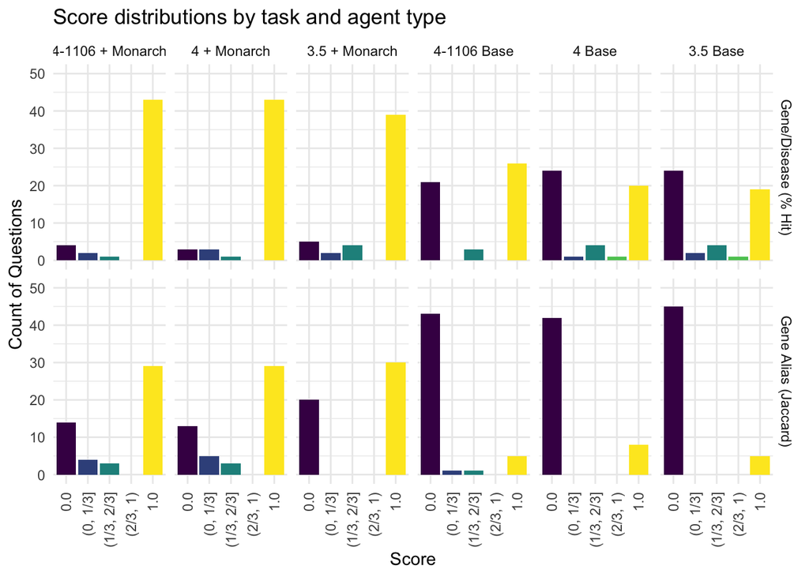

Update: 4-1106 represents results for the [recently released](https://openai.com/blog/new-models-and-developer-products-announced-at-devday) `gpt-4-1106-preview` model. Results seem to be similar (if not slightly better) than GPT-4 with Monarch integration; there is a noticeable bump in accuracy for Gene-Disease Association for the new model on its own (4-1106 Base).

Access to the Monarch API significantly improves answers. 3.5 and 4 perform comparably, not unsurprising for these simple 1- or 2-call operations. Both models can answer some questions on their own accord without Monarch help, with GPT-4 having only a slight advantage over 3.5. The change for Monarch + 3.5 to Monarch + 4 for Gene alias is interesting, with several incorrect answers moving to partially-correct. This task uses Jaccard index scoring, comparing gene names mentioned by the model against a single gold standard gene name. As a consequence scores are reduced if the agent includes additional synonyms, which GPT-4 is more likely to do:

Questions where 4-1106 + Monarch outperforms 3.5 + Monarch

question

goldstandard

3.5 + Monarch Score

4-1106 + Monarch Score

3.5 + Monarch Answer

4-1106 + Monarch Answer

What is the official gene symbol of PTH1?

PTH

0 ([link](https://github.com/monarch-initiative/oai-plugin-evals/blob/main/results/trial-gene_alias-monarch_assistant_gpt35-2f924ac4.json))

0.333333333333333 ([link](https://github.com/monarch-initiative/oai-plugin-evals/blob/main/results/trial-gene_alias-monarch_assistant_gpt4_1106_preview_-2f924ac4.json))

The official gene symbol for PTH1 is “PTH1” (SGD:S000001232).

The official gene symbol for “PTH1” is not uniquely defined, as there are several genes with similar symbols. Here are a few possibilities:

1. **PTH1R** - This is the official symbol for the Parathyroid Hormone 1 Receptor gene. HGNC:9608
2. **PTH** - This is the official symbol for the Parathyroid Hormone gene. HGNC:9606
3. **PTRH1** - This is the official symbol for the Peptidyl-tRNA Hydrolase 1 gene. HGNC:27039

If you are referring to a gene in a specific organism other than humans, there are also genes named “pth1” in other databases, such as in yeast (SGD:S000001232) and in zebrafish (ZFIN:ZDB-GENE-040623-1 for “pth1a” and ZFIN:ZDB-GENE-040623-2 for “pth1b”).

Please specify if you are looking for a gene in a particular organism or if you need more information about one of these genes.

What is the official gene symbol of MPS4B?

GLB1

0 ([link](https://github.com/monarch-initiative/oai-plugin-evals/blob/main/results/trial-gene_alias-monarch_assistant_gpt35-468b5c0d.json))

1 ([link](https://github.com/monarch-initiative/oai-plugin-evals/blob/main/results/trial-gene_alias-monarch_assistant_gpt4_1106_preview_-468b5c0d.json))

I’m sorry, but I couldn’t find the official gene symbol for MPS4B in the Monarch Initiative knowledge graph. It’s possible that the gene symbol is not available or not included in the database.

It appears that there are no results for the term “MPS4B” in the category of genes in the Monarch Initiative knowledge graph. MPS4B might not be the official gene symbol, or it may be known by a different name.

MPS4B typically refers to a type of Mucopolysaccharidosis, which is a disease rather than a gene. If you are looking for the gene associated with Mucopolysaccharidosis type IVB (Morquio Syndrome B), the gene you are looking for is likely GLB1, which encodes the enzyme beta-galactosidase.

Would you like me to search for the disease “Mucopolysaccharidosis type IVB” to find the associated gene, or do you have another gene symbol in mind?

What is the official gene symbol of GCS1?

MOGS

0 ([link](https://github.com/monarch-initiative/oai-plugin-evals/blob/main/results/trial-gene_alias-monarch_assistant_gpt35-5898901d.json))

0.25 ([link](https://github.com/monarch-initiative/oai-plugin-evals/blob/main/results/trial-gene_alias-monarch_assistant_gpt4_1106_preview_-5898901d.json))

The official gene symbol for GCS1 is “GCS1”.

The official gene symbol for “GCS1” can refer to different genes depending on the organism. Here are some of the entries for “GCS1”:

1. In yeast (Saccharomyces cerevisiae), “GCS1” is the official symbol, with the identifier SGD:S000002385.
2. In fruit fly (Drosophila melanogaster), “GCS1” is also the official symbol, with the identifier FB:FBgn0030289.
3. In humans, “GCS1” is associated with the gene symbol “ADAP1” (ArfGAP with dual PH domains 1), with the identifier HGNC:16486.
4. Another human gene associated with “GCS1” is “MOGS” (Mannosyl-Oligosaccharide Glucosidase), with the identifier HGNC:24862.
5. In fission yeast (Schizosaccharomyces pombe), “gcs1” is the official symbol, with the identifier PomBase:SPAC22F3.10c.
6. In rats, “Mogs” is associated with “GCS1”, with the identifier RGD:69240.
7. In mice, “Mogs” is associated with “GCS1”, with the identifier MGI:1929872.

Please specify the organism if you need the information for a particular species.

What is the official gene symbol of CXorf40B?

EOLA2

0 ([link](https://github.com/monarch-initiative/oai-plugin-evals/blob/main/results/trial-gene_alias-monarch_assistant_gpt35-64f45013.json))

1 ([link](https://github.com/monarch-initiative/oai-plugin-evals/blob/main/results/trial-gene_alias-monarch_assistant_gpt4_1106_preview_-64f45013.json))

The official gene symbol for CXorf40B is “CXorf40B”.

The official gene symbol for CXorf40B is **EOLA2**. Here is the [NCBI Gene entry for CXorf40B (EOLA2)](https://www.ncbi.nlm.nih.gov/gene/772269).

What is the official gene symbol of DCSCRIPT?

ZNF366

0 ([link](https://github.com/monarch-initiative/oai-plugin-evals/blob/main/results/trial-gene_alias-monarch_assistant_gpt35-8fecd49f.json))

0.5 ([link](https://github.com/monarch-initiative/oai-plugin-evals/blob/main/results/trial-gene_alias-monarch_assistant_gpt4_1106_preview_-8fecd49f.json))

The official gene symbol for DCSCRIPT is “znf366”.

The official gene symbol for DCSCRIPT is **ZNF366**. There are two entries in the Xenbase database:

1. **ZNF366** with the identifier Xenbase:XB-GENE-6464910
2. **ZNF366.L** with the identifier Xenbase:XB-GENE-6487571

Please note that these entries are specific to the Xenbase database, which is a resource for Xenopus (frog) genomics and development. If you are looking for information on the human gene, please let me know so I can provide the correct details.

What is the official gene symbol of 15-LOX?

ALOX15

0 ([link](https://github.com/monarch-initiative/oai-plugin-evals/blob/main/results/trial-gene_alias-monarch_assistant_gpt35-d2eb5063.json))

0.5 ([link](https://github.com/monarch-initiative/oai-plugin-evals/blob/main/results/trial-gene_alias-monarch_assistant_gpt4_1106_preview_-d2eb5063.json))

The official gene symbol for 15-LOX is ALOX15B.

The official gene symbols for 15-LOX are **ALOX15** and **ALOX15B**. Here are their identifiers:

- **ALOX15**: HGNC:433
- **ALOX15B**: HGNC:434

These symbols represent different genes that are part of the lipoxygenase family and are involved in the metabolism of fatty acids in humans.

What are genes related to Proteasome-associated autoinflammatory syndrome?

PSMB9, PSMG2, POMP, PSMB10

0.25 ([link](https://github.com/monarch-initiative/oai-plugin-evals/blob/main/results/trial-gene_disease_association-monarch_assistant_gpt35-376f1b14.json))

1 ([link](https://github.com/monarch-initiative/oai-plugin-evals/blob/main/results/trial-gene_disease_association-monarch_assistant_gpt4_1106_preview_-376f1b14.json))

The gene related to Proteasome-associated autoinflammatory syndrome 5 is [PSMB10](https://monarchinitiative.org/gene/HGNC:9538).

The following genes are related to Proteasome-associated autoinflammatory syndrome:

1. [PSMB10 (HGNC:9538)](https://monarchinitiative.org/gene/HGNC:9538) - Causal relationship
2. [PSMG2 (HGNC:24929)](https://monarchinitiative.org/gene/HGNC:24929) - Causal relationship
3. [PSMB8 (HGNC:9545)](https://monarchinitiative.org/gene/HGNC:9545) - Causal relationship (listed twice, indicating multiple sources or studies supporting this association)
4. [PSMB4 (HGNC:9541)](https://monarchinitiative.org/gene/HGNC:9541) - Causal relationship
5. [PSMB9 (HGNC:9546)](https://monarchinitiative.org/gene/HGNC:9546) - Causal relationship
6. [POMP (HGNC:20330)](https://monarchinitiative.org/gene/HGNC:20330) - Causal relationship

These genes have been identified as having a causal relationship with the syndrome, except for an additional correlation noted for PSMB8.

What are genes related to Spinal muscular atrophy with congenital bone fractures?

TRIP4, ASCC1

0.5 ([link](https://github.com/monarch-initiative/oai-plugin-evals/blob/main/results/trial-gene_disease_association-monarch_assistant_gpt35-5c5c4074.json))

1 ([link](https://github.com/monarch-initiative/oai-plugin-evals/blob/main/results/trial-gene_disease_association-monarch_assistant_gpt4_1106_preview_-5c5c4074.json))

The gene related to Spinal muscular atrophy with congenital bone fractures 1 is [TRIP4](https://monarchinitiative.org/gene/HGNC:12310).

The genes related to Spinal muscular atrophy with congenital bone fractures are:

1. For Spinal muscular atrophy with congenital bone fractures 1 (MONDO:0014806), the associated gene is **TRIP4**. You can find more information about this gene on the [Monarch Initiative website](https://monarchinitiative.org/gene/HGNC:12310).
2. For Spinal muscular atrophy with congenital bone fractures 2 (MONDO:0014807), the associated gene is **ASCC1**. More details can be found on the [Monarch Initiative website](https://monarchinitiative.org/gene/HGNC:24268).

What are genes related to Trichoepithelioma?

CYLD

0 ([link](https://github.com/monarch-initiative/oai-plugin-evals/blob/main/results/trial-gene_disease_association-monarch_assistant_gpt35-7c567ce6.json))

1 ([link](https://github.com/monarch-initiative/oai-plugin-evals/blob/main/results/trial-gene_disease_association-monarch_assistant_gpt4_1106_preview_-7c567ce6.json))

There are no specific genes directly associated with Trichoepithelioma in the Monarch Initiative knowledge graph. Trichoepithelioma is a benign neoplasm that arises from the skin and is characterized by the presence of nests of monomorphic basaloid cells forming small cysts that contain keratin. It is often associated with other conditions such as Rombo syndrome, which is characterized by vermiculate atrophoderma, milia, hypotrichosis, trichoepitheliomas, peripheral vasodilation with cyanosis, and basal cell carcinomas.

If you have any other questions, feel free to ask!

The gene associated with familial multiple trichoepithelioma (MONDO:0011114) is CYLD. This gene has been identified as having a causal relationship with the disease.

For more information about the CYLD gene, you can visit the [Monarch Initiative gene page](https://monarchinitiative.org/gene/HGNC:2584).

What are genes related to Gastrointestinal defects and immunodeficiency syndrome?

PI4KA, TTC7A

0.5 ([link](https://github.com/monarch-initiative/oai-plugin-evals/blob/main/results/trial-gene_disease_association-monarch_assistant_gpt35-fa8b72a0.json))

1 ([link](https://github.com/monarch-initiative/oai-plugin-evals/blob/main/results/trial-gene_disease_association-monarch_assistant_gpt4_1106_preview_-fa8b72a0.json))

The gene related to Gastrointestinal defects and immunodeficiency syndrome is [PI4KA](https://monarchinitiative.org/gene/HGNC:8983).

The genes related to Gastrointestinal defects and immunodeficiency syndrome (MONDO:0030831) are:

1. **PI4KA** (HGNC:8983) - This gene has a causal relationship with the syndrome.
2. **TTC7A** (HGNC:19750) - This gene is both causally related and correlated with the syndrome.

For more information, you can visit the [Monarch Initiative](https://monarchinitiative.org/disease/MONDO:0030831) page for Gastrointestinal defects and immunodeficiency syndrome.

The score links in the above table open the full trial information, including the function calls, responses, and final model answers. Digging into the `PTH` examples shows that both models make the same function call and get the same result, but 3.5 + Monarch reports the first result only (`PTH1`, not the answer sought). GPT-4 is more thorough in its summary of the results. The system prompts specify to include markdown-formatted links to the Monarch Initiative for all results, so this is possibly due to GPT-4’s improved instruction-following capabilities.

The following questions were answered more accurately by 4 Base than 4 + Monarch, an unexpected result:

Questions where 4 Base outperformed 4 + Monarch

[output not shown]

Investigating the the score of `0.25` for Monarch GPT4’s answer to “What are genes related to Proteasme-associated autoinflammatory syndrome”, we can see that the agent called the `search` endpoint with the string `"Proteasome-associated autoinflammatory syndrome"`, and while the response included several matching diseases, `MONDO:0030924 proteasome-associated autoinflammatory syndrome 5` (PRAAS5) was listed first; the followup call to `get_disease_gene_associations` for this notes only a single causal association with `PSMB10`. The more general entry `MONDO:0009726 proteosome-associated autoinflammatory syndrome` (PRAAS) was later in the search results and would have pulled PMSB4, PSMB8, PSMB9, PSMB10, and POMP had the model chosen it. 4 Base in this case answered with PSMB8, PSMB9, PSMB4, PSMA3, and POMP. This answer misses `PSMB10` and adds PSMA3, which OMIM notes is associated with [proeteasome-associated autoinflammatory syndrome 1](https://www.omim.org/entry/256040) (PRAAS1). PSMG2 is not present in either answer (nor Monarch for general PRAAS) but also associated with PRAAS1 by OMIM.

Given that GPT-4 is a much larger model, we might expect it to have improved memorization of training data and perform better than 3.5 on tasks like disease-gene association. We find several examples of the opposite, but in some cases at least these are due different potential correct answers.

Questions where 4 Base score differs from 3.5 Base

[output not shown]

To take an example, for sensironeural deafness question, 3.5 Base reports example genes as “COQ6”, “ATP6V1B1”, and “BSND”, while 4 Base reports genes associated with Alport Syndrome, “COL4A3”. “COL4A4”, and “COL4A5”. All of these answers appear to address the question - COQ6 is causal for [familial steroid-resistant nephrotic syndrome with sensorineural deafness](https://monarchinitiative.org/MONDO:0013836), ATP6V1B1 is causal for [renal tubular acidosis, distal, 2, with progressive sensorineural hearing loss](https://monarchinitiative.org/MONDO:0009968), and [Alport Syndrome](https://monarchinitiative.org/MONDO:0018965) is indeed caused by the three genes listed and is characterized by progressive renal insufficiency and hearing loss.

Considering Haim-Munk syndrome where GPT-4 outperforms GPT 3.5, 4 gets the answer exactly correct, while 3.5 describes the syndrome and mentions that “The exact genes related to Haim-Munk syndrome have not been identified yet.” This is incorrect, and OMIM [notes](https://www.omim.org/entry/245010) that the relationship with CTSC was discovered circa 2000.

## Discussion

Although these results are good, there are several avenues for improvement throughout the stack:

- Improved prompting, for example to encourage verbosity/completeness and selecting the best result from a returned list rather than the first
- Improvements in the API wrapper, for example to return more results, re-rank results for better interpretation, or include more contextual information
- Improvements in the backend Monarch API, for example to improve search relevance

The scoring mechanisms suggested by the GeneTuring paper for our two tasks represent different goals: a Jaccard-index score for the gene alias task penalizes answers with multiple name options, even if they are all ‘correct’ (but not the expected goldstandard answer). By contrast, the disease to gene accuracy score does not penalize associations listed beyond the expected gold standards, even if they are incorrect (note that we do not look for this). These scores also penalize creative-but-correct answers as illustrated by the renal dysfunction + deafness example.

Lastly, these tests might be seen as convoluted unit tests, with a couple of AI models in the middle. This is particularly the case for the disease-gene association task, where the benchmark data is sourced from OMIM which also feeds Monarch. We should thus expect good results for this task, moderated by the performance of the keyword search, wrapper API, and model-based information extraction and summarization performance.

## Appendix

All questions and results for perusal (to filter by scores, try using e.g. `0 (` in the search to avoid matching parts of the link URLs.)

All questions and scores

| module | question | goldstandard | 4 Base Score | 3.5 Base Score | 4 + Monarch Score | 3.5 + Monarch Score |
| --- | --- | --- | --- | --- | --- | --- |
| Gene alias | What is the official gene symbol of HsT1192? | SYT4 | 0 (<a href="https://github.com/monarch-initiative/oai-plugin-evals/blob/main/results/trial-gene_alias-dummy_agent_gpt4-048a11e2.json" target="_blank">link</a>) | 0 (<a href="https://github.com/monarch-initiative/oai-plugin-evals/blob/main/results/trial-gene_alias-dummy_agent_gpt35-048a11e2.json" target="_blank">link</a>) | NA | NA |
| Gene alias | What is the official gene symbol of IMD20? | FCGR3A | 0 (<a href="https://github.com/monarch-initiative/oai-plugin-evals/blob/main/results/trial-gene_alias-dummy_agent_gpt4-06099c9e.json" target="_blank">link</a>) | 0 (<a href="https://github.com/monarch-initiative/oai-plugin-evals/blob/main/results/trial-gene_alias-dummy_agent_gpt35-06099c9e.json" target="_blank">link</a>) | 0 (<a href="https://github.com/monarch-initiative/oai-plugin-evals/blob/main/results/trial-gene_alias-monarch_assistant_gpt4-06099c9e.json" target="_blank">link</a>) | 0 (<a href="https://github.com/monarch-initiative/oai-plugin-evals/blob/main/results/trial-gene_alias-monarch_assistant_gpt35-06099c9e.json" target="_blank">link</a>) |
| Gene alias | What is the official gene symbol of PFDN3? | VBP1 | 0 (<a href="https://github.com/monarch-initiative/oai-plugin-evals/blob/main/results/trial-gene_alias-dummy_agent_gpt4-137c346e.json" target="_blank">link</a>) | 0 (<a href="https://github.com/monarch-initiative/oai-plugin-evals/blob/main/results/trial-gene_alias-dummy_agent_gpt35-137c346e.json" target="_blank">link</a>) | NA | NA |
| Gene alias | What is the official gene symbol of RSG1? | CPLANE2 | 0 (<a href="https://github.com/monarch-initiative/oai-plugin-evals/blob/main/results/trial-gene_alias-dummy_agent_gpt4-18a189af.json" target="_blank">link</a>) | 0 (<a href="https://github.com/monarch-initiative/oai-plugin-evals/blob/main/results/trial-gene_alias-dummy_agent_gpt35-18a189af.json" target="_blank">link</a>) | 0 (<a href="https://github.com/monarch-initiative/oai-plugin-evals/blob/main/results/trial-gene_alias-monarch_assistant_gpt4-18a189af.json" target="_blank">link</a>) | 0 (<a href="https://github.com/monarch-initiative/oai-plugin-evals/blob/main/results/trial-gene_alias-monarch_assistant_gpt35-18a189af.json" target="_blank">link</a>) |
| Gene alias | What is the official gene symbol of LEP9? | LCE2A | 0 (<a href="https://github.com/monarch-initiative/oai-plugin-evals/blob/main/results/trial-gene_alias-dummy_agent_gpt4-2bb52099.json" target="_blank">link</a>) | 0 (<a href="https://github.com/monarch-initiative/oai-plugin-evals/blob/main/results/trial-gene_alias-dummy_agent_gpt35-2bb52099.json" target="_blank">link</a>) | NA | NA |
| Gene alias | What is the official gene symbol of LMP10? | PSMB10 | 1 (<a href="https://github.com/monarch-initiative/oai-plugin-evals/blob/main/results/trial-gene_alias-dummy_agent_gpt4-2df6d63f.json" target="_blank">link</a>) | 1 (<a href="https://github.com/monarch-initiative/oai-plugin-evals/blob/main/results/trial-gene_alias-dummy_agent_gpt35-2df6d63f.json" target="_blank">link</a>) | 1 (<a href="https://github.com/monarch-initiative/oai-plugin-evals/blob/main/results/trial-gene_alias-monarch_assistant_gpt4-2df6d63f.json" target="_blank">link</a>) | 1 (<a href="https://github.com/monarch-initiative/oai-plugin-evals/blob/main/results/trial-gene_alias-monarch_assistant_gpt35-2df6d63f.json" target="_blank">link</a>) |
| Gene alias | What is the official gene symbol of CTTNBP1? | SHANK2 | 0 (<a href="https://github.com/monarch-initiative/oai-plugin-evals/blob/main/results/trial-gene_alias-dummy_agent_gpt4-2e70096a.json" target="_blank">link</a>) | 0 (<a href="https://github.com/monarch-initiative/oai-plugin-evals/blob/main/results/trial-gene_alias-dummy_agent_gpt35-2e70096a.json" target="_blank">link</a>) | NA | NA |
| Gene alias | What is the official gene symbol of SGEF? | ARHGEF26 | NA | 0 (<a href="https://github.com/monarch-initiative/oai-plugin-evals/blob/main/results/trial-gene_alias-dummy_agent_gpt35-2f85ba1a.json" target="_blank">link</a>) | NA | NA |
| Gene alias | What is the official gene symbol of PTH1? | PTH | NA | 0 (<a href="https://github.com/monarch-initiative/oai-plugin-evals/blob/main/results/trial-gene_alias-dummy_agent_gpt35-2f924ac4.json" target="_blank">link</a>) | NA | 0 (<a href="https://github.com/monarch-initiative/oai-plugin-evals/blob/main/results/trial-gene_alias-monarch_assistant_gpt35-2f924ac4.json" target="_blank">link</a>) |
| Gene alias | What is the official gene symbol of beta3Gn-T8? | B3GNT8 | 1 (<a href="https://github.com/monarch-initiative/oai-plugin-evals/blob/main/results/trial-gene_alias-dummy_agent_gpt4-38db51ed.json" target="_blank">link</a>) | 1 (<a href="https://github.com/monarch-initiative/oai-plugin-evals/blob/main/results/trial-gene_alias-dummy_agent_gpt35-38db51ed.json" target="_blank">link</a>) | 1 (<a href="https://github.com/monarch-initiative/oai-plugin-evals/blob/main/results/trial-gene_alias-monarch_assistant_gpt4-38db51ed.json" target="_blank">link</a>) | 1 (<a href="https://github.com/monarch-initiative/oai-plugin-evals/blob/main/results/trial-gene_alias-monarch_assistant_gpt35-38db51ed.json" target="_blank">link</a>) |

[output cut: 174 more lines]

[^1]: The [Cancer Genetics BioNLP](https://huggingface.co/datasets/bigbio/bionlp_st_2013_cg/viewer/bionlp_st_2013_cg_source) benchmark is the only other I know of, focusing on entity extraction but also providing some association and equivalence information.